# Notebook Setup

```python
!which python3
```

```
/Library/Frameworks/Python.framework/Versions/3.11/bin/python3
```

```python
%load_ext autoreload
%autoreload 2
%matplotlib inline
# these are just couple extensions to help with certain things
```

```
The autoreload extension is already loaded. To reload it, use:
  %reload_ext autoreload
```

```python
 # Standard imports
import os

# Third-party imports
import pandas as pd
import numpy as np
import matplotlib.pyplot as plt
import seaborn as sns

# Local imports
```

```python
sns.set() # this will make the notebook use seaborn plotting styles
```

# Load Data

```python
data = pd.read_csv('IRIS.csv')
```

```python
data.columns
```

```
Index(['sepal_length', 'sepal_width', 'petal_length', 'petal_width',
       'species'],
      dtype='object')
```

```python
df = data.drop(columns=["species"])
df.head()
```

|  | sepal_length | sepal_width | petal_length | petal_width |
| --- | --- | --- | --- | --- |
| 0 | 5.1 | 3.5 | 1.4 | 0.2 |
| 1 | 4.9 | 3.0 | 1.4 | 0.2 |
| 2 | 4.7 | 3.2 | 1.3 | 0.2 |
| 3 | 4.6 | 3.1 | 1.5 | 0.2 |
| 4 | 5.0 | 3.6 | 1.4 | 0.2 |

```python
df["target"] = pd.Categorical(data["species"]).codes
# df["target"] = data["species"].map({"name":0}) # this way will work too write the name and its relative value you want to use
df
```

|  | sepal_length | sepal_width | petal_length | petal_width | target |
| --- | --- | --- | --- | --- | --- |
| 0 | 5.1 | 3.5 | 1.4 | 0.2 | 0 |
| 1 | 4.9 | 3.0 | 1.4 | 0.2 | 0 |
| 2 | 4.7 | 3.2 | 1.3 | 0.2 | 0 |
| 3 | 4.6 | 3.1 | 1.5 | 0.2 | 0 |
| 4 | 5.0 | 3.6 | 1.4 | 0.2 | 0 |
| ... | ... | ... | ... | ... | ... |
| 145 | 6.7 | 3.0 | 5.2 | 2.3 | 2 |
| 146 | 6.3 | 2.5 | 5.0 | 1.9 | 2 |
| 147 | 6.5 | 3.0 | 5.2 | 2.0 | 2 |
| 148 | 6.2 | 3.4 | 5.4 | 2.3 | 2 |
| 149 | 5.9 | 3.0 | 5.1 | 1.8 | 2 |

150 rows × 5 columns

```python
df.describe()
```

|  | sepal_length | sepal_width | petal_length | petal_width | target |
| --- | --- | --- | --- | --- | --- |
| count | 150.000000 | 150.000000 | 150.000000 | 150.000000 | 150.000000 |
| mean | 5.843333 | 3.054000 | 3.758667 | 1.198667 | 1.000000 |
| std | 0.828066 | 0.433594 | 1.764420 | 0.763161 | 0.819232 |
| min | 4.300000 | 2.000000 | 1.000000 | 0.100000 | 0.000000 |
| 25% | 5.100000 | 2.800000 | 1.600000 | 0.300000 | 0.000000 |
| 50% | 5.800000 | 3.000000 | 4.350000 | 1.300000 | 1.000000 |
| 75% | 6.400000 | 3.300000 | 5.100000 | 1.800000 | 2.000000 |
| max | 7.900000 | 4.400000 | 6.900000 | 2.500000 | 2.000000 |

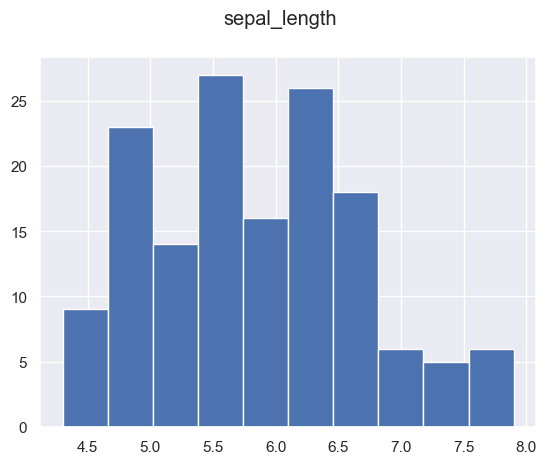

```python
df["sepal_length"].hist()
plt.suptitle("sepal_length")
plt.show()
```

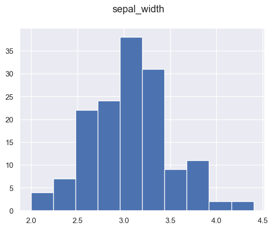

```python
df["sepal_width"].hist()
plt.suptitle("sepal_width")
plt.show()
```

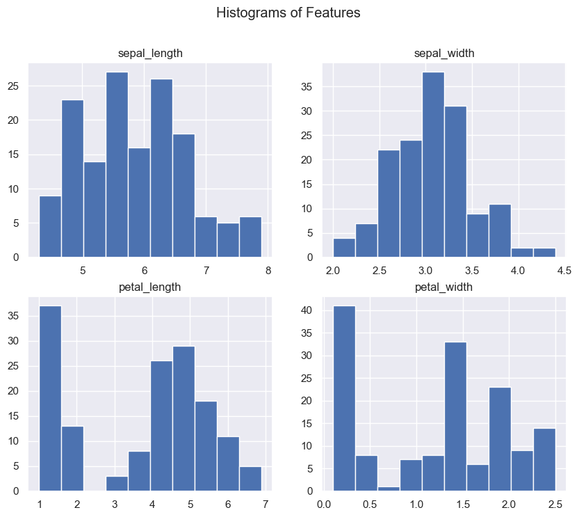

```python
# Assuming df contains your dataset
features = ["sepal_length", "sepal_width", "petal_length", "petal_width"]

fig, axes = plt.subplots(2, 2, figsize=(10, 8))  # Create a 2x2 grid
fig.suptitle("Histograms of Features")  # Set the overall title

# Loop through features and axes
for ax, feature in zip(axes.ravel(), features):
    df[feature].hist(ax=ax)  # Plot histogram
    ax.set_title(feature)  # Set title for each subplot

plt.show()
```

```python
df["target"]
```

```
0      0
1      0
2      0
3      0
4      0
      ..
145    2
146    2
147    2
148    2
149    2
Name: target, Length: 150, dtype: int8
```

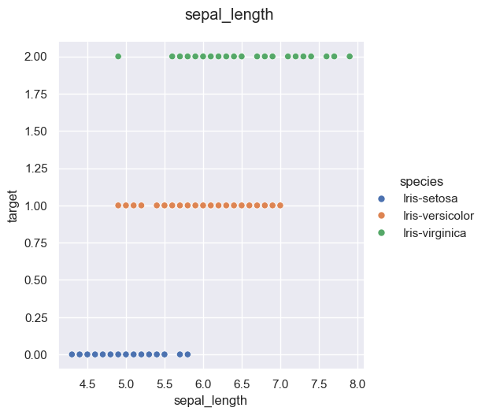

```python
# df["sepal_length"].hist()
# plt.suptitle("sepal_length")
# plt.show()
col = "sepal_length"
sns.relplot(x=col, y="target", hue=data["species"], data=df )
plt.suptitle(col, y=1.05)
plt.show()
```

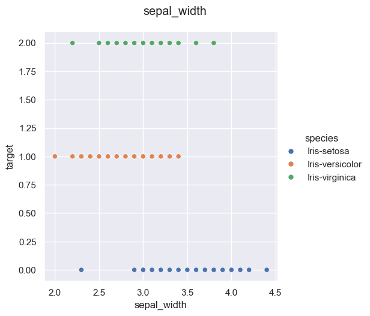

```python
col = "sepal_width"
sns.relplot(x=col, y="target", hue=data["species"], data=df )
plt.suptitle(col, y=1.05)
plt.show()
```

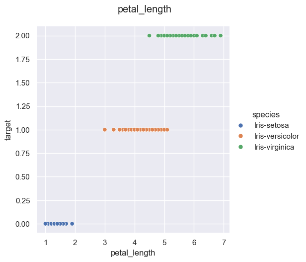

```python
col = "petal_length"
sns.relplot(x=col, y="target", hue=data["species"], data=df )
plt.suptitle(col, y=1.05)
plt.show()
```

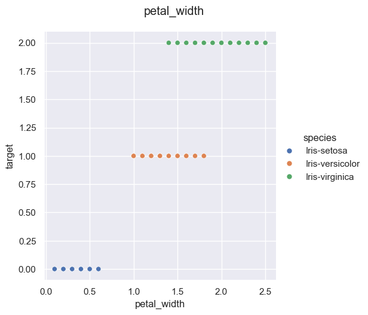

```python
col = "petal_width"
sns.relplot(x=col, y="target", hue=data["species"], data=df )
plt.suptitle(col, y=1.05)
plt.show()
```

# EDA (Pair Plots):

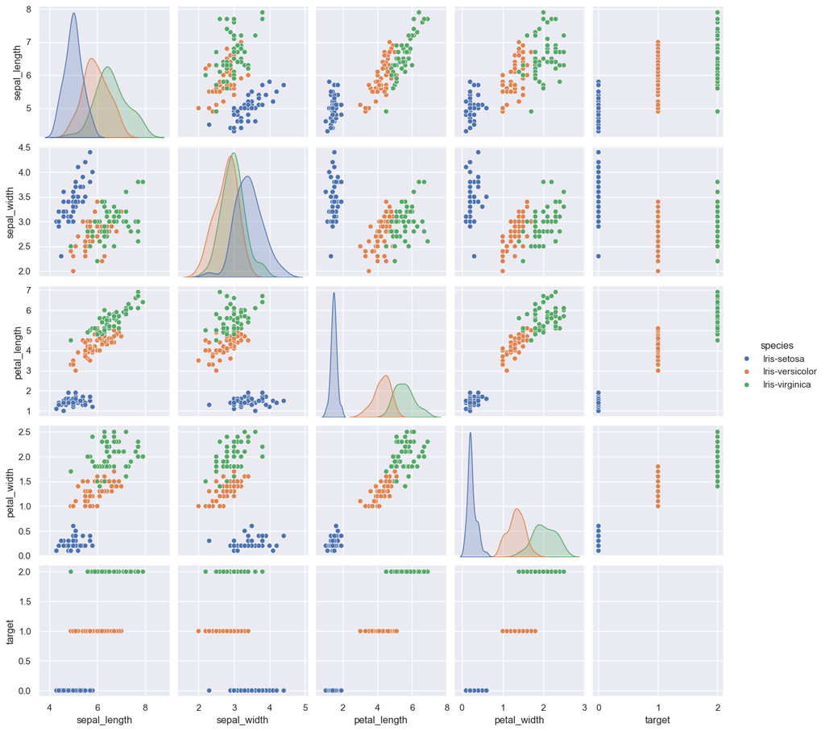

```python
df["species"] = data["species"]
sns.pairplot(df, hue="species")

# sns.pairplot(df)
```

# Train test split

You always want to evaluate your final model on a test set that has not been used at all in the training process. So we split off a test set here

(Note: When using cross-validation we could technically use the same data but its best practice it used separate data for testing)

```python
from sklearn.model_selection import train_test_split
```

```python
df_train, df_test = train_test_split(df, test_size=0.25)
```

```python
df_train.shape
```

```
(112, 6)
```

```python
df_test.shape
```

```
(38, 6)
```

# Preparing our data for modeling

This involves splitting the data back into plain NumPy arrays

```python
X_train = df_train.drop(columns=[ "species", "target"]).to_numpy() # so we drop these two columns and converts to the numpy array for model to train on
y_train = df_train["target"].to_numpy()
```

```python
X_train.shape
```

```
(112, 4)
```

# Modeling - What is our baseline?

What is the simplest model we can think of?

In this case, if our baseline model is just randomly guesssing the species of flower, or guesssing a single species for every data point, we would expect to have a model accuracy of 0.33 or 33%, since we have 3 different classes which are evenly balanced (50 data points each).

So our models should atleast beat 33% accuracy.

# Modeling - Simple Manual Model

Let's manually look at our data and decide some cutoff points for classification.

```python
data["species"].unique()
```

```
array(['Iris-setosa', 'Iris-versicolor', 'Iris-virginica'], dtype=object)
```

```python
def single_feature_prediction(petal_length):
    """Predicts the Iris species given the petal length."""
    if petal_length < 2.5:
        return 0
    elif petal_length < 4.8:
        return 1
    else:
        return 2

# This is kindof very basic view of what decision trees ml model do in the backend bunch of if else statements
```

```python
df_train.columns
```

```
Index(['sepal_length', 'sepal_width', 'petal_length', 'petal_width', 'target',
       'species'],
      dtype='object')
```

```python
X_train[:,2] # ':' is to select all the rows 2 is the 'petal_length' column
```

```
array([4.5, 6.4, 5.9, 1.4, 1.4, 4.7, 1.6, 5.3, 4.9, 5.1, 1.7, 6.3, 1.5,
       5.2, 3.5, 1.4, 4.2, 1.5, 3.9, 6. , 1.3, 4.2, 4. , 5.1, 1.6, 1.4,
       1.3, 3.6, 1.4, 5. , 1.5, 5.5, 4.6, 1.6, 4.5, 4.9, 1.6, 5. , 4.5,
       1.5, 3.3, 1.2, 1.4, 1.6, 1.4, 1.2, 1.7, 6. , 1.9, 4. , 4.4, 3.8,
       5.7, 3.5, 3.7, 4.3, 4.5, 4.4, 6.1, 1.5, 1.5, 5.6, 3.3, 4.1, 6.1,
       1.3, 4.5, 1.5, 4. , 1.4, 1.3, 5.6, 5.7, 3. , 6.9, 1.5, 6.6, 5.1,
       4.7, 6.7, 1.4, 1.5, 1.5, 4.8, 5.8, 4.5, 4.8, 5.6, 4. , 4.2, 5.3,
       1.4, 1.5, 5.9, 4.3, 5.1, 4.1, 4.7, 1.3, 1.1, 5. , 3.9, 5.6, 4.9,
       5.6, 5.1, 5.8, 4.4, 1.3, 5.7, 5.6, 5. ])
```

```python
manual_y_predictions = np.array([single_feature_prediction(val) for val in X_train[:,2] ])
```

```python
manual_y_predictions == y_train  # this basically is gonna give true whenever the prediction is correct else false
```

```
array([ True,  True,  True,  True,  True,  True,  True,  True,  True,
       False,  True,  True,  True,  True,  True,  True,  True,  True,
        True,  True,  True,  True,  True,  True,  True,  True,  True,
        True,  True,  True,  True,  True,  True,  True, False, False,
        True,  True,  True,  True,  True,  True,  True,  True,  True,
        True,  True,  True,  True,  True,  True,  True,  True,  True,
        True,  True,  True,  True,  True,  True,  True,  True,  True,
        True,  True,  True,  True,  True,  True,  True,  True,  True,
        True,  True,  True,  True,  True,  True,  True,  True,  True,
        True,  True, False,  True,  True,  True,  True,  True,  True,
        True,  True,  True,  True,  True,  True,  True,  True,  True,
        True, False,  True,  True, False,  True,  True,  True,  True,
        True,  True,  True,  True])
```

```python
manual_model_accuracy = float(np.mean(manual_y_predictions == y_train)) # this way we can find accuracy all true values as 1 and false as 0 and takes it average
```

```python
model_accuracies=[]
model_accuracies.append([manual_model_accuracy,"Manual"])

print(f"Manual model accuracy {manual_model_accuracy * 100:.2f}% ")
```

```
Manual model accuracy 94.64%
```

# Modeling - Logistic Regression

```python
 from sklearn.linear_model import LogisticRegression
```

# Using a validation set to evaluate our model

This is different from the original test data which we split we will use that later to test all our models here we split a portion of the training dataset

```python
Xt, Xv, yt, yv = train_test_split(X_train, y_train, test_size=0.25)
# Xt is X_train and Xv is X_validation
```

```python
Xt.shape
```

```
(84, 4)
```

```python
Xv.shape
```

```
(28, 4)
```

```python
model = LogisticRegression()
```

```python
# model.fit(X_train, y_train)
model.fit(Xt, yt)
```

```
LogisticRegression()
```

```python
y_pred = model.predict(Xv)
np.mean(y_pred == yv)
```

```
1.0
```

```python
model.score(Xv,yv)
# both this and above doing the same thing to show that how it calculates the score
```

```
1.0
```

```python
# model.score(X_train, y_train) # This right here is wrong as you never wanna evaluate your model on the same data that was used for training
```

# Using Cross-Validation to evaluate our model

```python
from sklearn.model_selection import cross_val_score, cross_val_predict
```

```python
model = LogisticRegression(max_iter  = 200)
```

```python
accuracies = cross_val_score(estimator = model , X = X_train, y = y_train, cv = 5, scoring = "accuracy") # you dont really have to do estimator = X = y =
# as those 3 its already expecting as the first 3 values

accuracies
```

```
array([0.95652174, 0.91304348, 1.        , 0.95454545, 0.95454545])
```

```python
# this gives the scores from all those 5 splits where 1/5 of data is tested and 4/5 data is used as training
```

```python
np.mean(accuracies)
```

```
0.9557312252964426
```

# Where are we misclassifying points?

```python
y_pred = cross_val_predict(model, X_train, y_train, cv = 5)
```

```python
predicted_correctly_mask = y_pred == y_train # basically like above y_pred == y_train will give us boolean array of where data was right and wrong
```

```python
# this is using cross validation so basically training on 4/5 and testing on 1/5 data and each of this y_pred the value is when it was not tested on that

# like example it will for first 1/5 data check on portion when other 4/5 was used to train and so on

# so basically it meshes together the different predictions for different parts
```

```python
X_train[predicted_correctly_mask] # see here we see the data points where predictions were correct
X_train[~predicted_correctly_mask] # see here we see the data points where predictions were incorrect
```

```
array([[6. , 2.7, 5.1, 1.6],
       [6. , 2.2, 5. , 1.5],
       [4.9, 2.5, 4.5, 1.7],
       [6. , 3. , 4.8, 1.8],
       [6.7, 3. , 5. , 1.7]])
```

```python
df_predictions = df_train.copy()
```

```python
df_predictions["correct_prediction"] = predicted_correctly_mask
```

```python
df_predictions["prediction"] = y_pred
```

```python
df_predictions["prediction_label"] = df_predictions["prediction"].map({0:"Iris-setosa", 1:"Iris-versicolor", 2:"Iris-virginica"})
```

```python
df_predictions.head()
```

|  | sepal_length | sepal_width | petal_length | petal_width | target | species | correct_prediction | prediction | prediction_label |
| --- | --- | --- | --- | --- | --- | --- | --- | --- | --- |
| 55 | 5.7 | 2.8 | 4.5 | 1.3 | 1 | Iris-versicolor | True | 1 | Iris-versicolor |
| 131 | 7.9 | 3.8 | 6.4 | 2.0 | 2 | Iris-virginica | True | 2 | Iris-virginica |
| 143 | 6.8 | 3.2 | 5.9 | 2.3 | 2 | Iris-virginica | True | 2 | Iris-virginica |
| 49 | 5.0 | 3.3 | 1.4 | 0.2 | 0 | Iris-setosa | True | 0 | Iris-setosa |
| 17 | 5.1 | 3.5 | 1.4 | 0.3 | 0 | Iris-setosa | True | 0 | Iris-setosa |

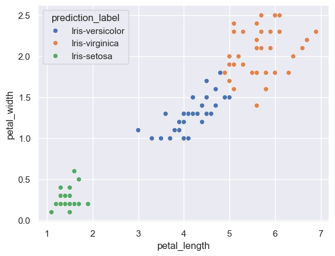

```python
sns.scatterplot(x="petal_length", y="petal_width", hue="prediction_label", data=df_predictions)
```

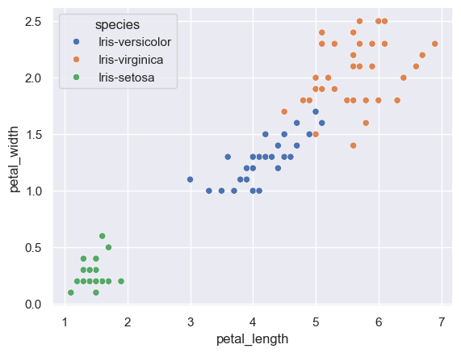

```python
sns.scatterplot(x="petal_length", y="petal_width", hue="species", data=df_predictions)
```

```python
def plot_incorrect_predictions(df_predictions, x_axis_feature, y_axis_feature):
    fig, axs = plt.subplots(2, 2, figsize=(10,10))
    axs = axs.flatten()
    sns.scatterplot(x=x_axis_feature, y=y_axis_feature, hue="prediction_label", data=df_predictions, ax=axs[0])
    sns.scatterplot(x=x_axis_feature, y=y_axis_feature, hue="species", data=df_predictions, ax=axs[1])
    sns.scatterplot(x=x_axis_feature, y=y_axis_feature, hue="correct_prediction", data=df_predictions, ax=axs[2])
    axs[3].set_visible(False)

    plt.show()
```

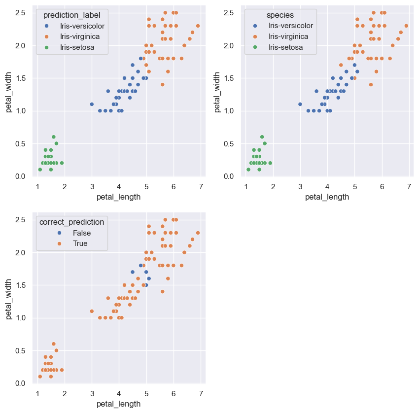

```python
plot_incorrect_predictions(df_predictions, "petal_length", "petal_width")
```